# Microbiome in diffuse type 2 chronic rhinosinusitis

Author

Fabio Ryser

Published

May 7, 2024

## Introduction

In the IMMUNOPOLYP study we sampled 27 patients with chronic rhinosinusitis treated with dupilumab 300mg s.c. every other week. We collected nasal swabs and stool samples during the course of treatment. We performed 16S shotgun-metagenomics analysis.

## Load packages

Prior to the metagenomics data analysis we load all necessary packages.

```r
library(openxlsx)
library(DECIPHER)
library(dada2)
library(readr)
library(seqinr)
library(phyloseq)
library(vegan)
library(ggplot2)
library(viridis)
library(dplyr)
library(gss)
library(coda4microbiome)
library(pheatmap)
library(ggpubr)
library(microbiome)
library(mia)
library(ggrepel)
library(metagenomeSeq)
library(MicrobiomeStat)
library(RColorBrewer)
library(DESeq2)
library(rstatix)
library(tidyr)
```

## Data import

For further information about cleaning data and the preliminary analysis of ASV signals please refer to [DADA2 package](https://www.bioconductor.org/packages/release/bioc/html/dada2.html) and the corresponding tutorials on the [github page](https://benjjneb.github.io/dada2/tutorial.html). The data provided in this example have already been cleaned and the taxonomy assignement has been conducted. We start by load the packaged ASV counts without contamination and the ASV taxonomy as well as the sample metadata.

```r
# load our ASV count data from the shotgun metagenomic analysis
count_tab <- read.table("//filer300/USERS3001/I0331555/Documents/IMMUNOPOLYP/MIKROPOLYP/ASVs_counts-no-contam.tsv", header=T, row.names=1,
                        check.names=F, sep="\t")

# load our taxnomy table (output of the assinging taxonomy according to DADA2 package)
tax_tab <- as.matrix(read.table("//filer300/USERS3001/I0331555/Documents/IMMUNOPOLYP/MIKROPOLYP/ASVs_taxonomy.tsv", header=T,
                                row.names=1, check.names=F, sep="\t"))
# match ASV to the taxonomy
ASV <- rownames(count_tab)
tax_tab <- cbind(tax_tab, ASV)
tax_tab <- as.data.frame(tax_tab)
rownames(tax_tab) <- tax_tab$ASV
# save as matrix for later
tax_tab <- as.matrix(tax_tab)

# load the sample information data (only nasal samples)
sample1 <- read.xlsx("//filer300/USERS3001/I0331555/Documents/IMMUNOPOLYP/MIKROPOLYP/sample_information_nasal.xlsx")

sample_info_tab <- read.table("//filer300/USERS3001/I0331555/Documents/IMMUNOPOLYP/MIKROPOLYP/sample_information_nasal.tsv", header=T, row.names=1,
                              check.names=F, sep="\t")

# load the sample information for stool samples
sample_info_stool <- read.table("//filer300/USERS3001/I0331555/Documents/IMMUNOPOLYP/MIKROPOLYP/sample_information_stool.tsv", header=T, row.names=1,
                              check.names=F, sep="\t")
sample2 <- read.xlsx("//filer300/USERS3001/I0331555/Documents/IMMUNOPOLYP/MIKROPOLYP/sample_information_stool.xlsx")

# merge all stool sample data to one dataframe
sample_info_stool$SampleID <- rownames(sample_info_stool)
sample_info_stool <- merge(sample_info_stool, sample2, by = "treat")
rownames(sample_info_stool) <- sample_info_stool$SampleID
sample_info_stool$Time <- factor(sample_info_stool$Time, levels = c("healthy", "0", "28", "90", "180"))

# merge all nasal sample data to one dataframe
sample_info_tab$SampleID <- rownames(sample_info_tab)
sample_info_tab <- merge(sample_info_tab, sample1, by = "treat")
rownames(sample_info_tab) <- sample_info_tab$SampleID
sample_info_tab$Time <- factor(sample_info_tab$Time, levels = c("healthy", "0", "28", "90", "180"))

# subset the count table to only nasal microbiome and exclude all stool samples
count_tab_nasal <- count_tab[, colnames(count_tab) %in% sample_info_tab$SampleID]

# subset the count table to only stool microbiome and exclude all stool samples
count_tab_stool <- count_tab[, colnames(count_tab) %in% sample_info_stool$SampleID]
count_tab_stool <- as.data.frame(count_tab_stool)
```

## Designing a phyloseq object

To proceed with the microbiome analysis we use the phyloseq package and design a phyloseq object with the count table, taxonomy table and the sample data.

```r
# assign the right tables to the right matrices
count_tab_phy <- otu_table(count_tab_nasal, taxa_are_rows=T)
tax_tab_phy <- tax_table(tax_tab)
sample_info_tab_phy <- sample_data(sample_info_tab)

# merge all table to a S4 object
ASV_physeq <- phyloseq(count_tab_phy, tax_tab_phy, sample_info_tab_phy)
```

We do the same for our stool samples.

```r
# assign the right tables to the right matrices
count_tab_phy_stool <- otu_table(count_tab_stool, taxa_are_rows=T)
tax_tab_phy_stool <- tax_table(tax_tab)
sample_info_tab_phy_stool <- sample_data(sample_info_stool)

# merge all table to a S4 object
ASV_physeq_stool <- phyloseq(count_tab_phy_stool, tax_tab_phy_stool, sample_info_tab_phy_stool)
```

# Alpha Diversity

Because the cleaning of the data has already been done in the preliminary analysis using DADA2 package, we can start straight forward with the analysis of the alpha diversity following the [phyloseq workflow](https://joey711.github.io/phyloseq/plot_richness-examples.html) and the [microbiome worflow](https://microbiome.github.io/tutorials/).

```r
# create boxplot including shannon diversity with wilcoxan rank test
p.shannon <- boxplot_alpha(ASV_physeq,
                           index = "shannon",
                           x_var = "Time") +
  stat_compare_means(method = "wilcox", step.increase = 0.06,
                     comparisons = list(c("healthy", "0"), c("healthy", "28"), c("healthy", "90"), c("healthy", "180"), c("0", "28"), c("0", "90"), c("0", "180"))) +
  scale_fill_viridis(discrete = TRUE, alpha = 1, option="viridis")+
  theme_bw()+
  ylab("Shannon-Diversity")+
  labs(title = "Nasal Microbiome")

p.chao <- boxplot_alpha(ASV_physeq,
                           index = "chao1",
                           x_var = "Time") +
  stat_compare_means(method = "wilcox", step.increase = 0.06,
                     comparisons = list(c("healthy", "0"), c("healthy", "28"), c("healthy", "90"), c("healthy", "180"), c("0", "28"), c("0", "90"), c("0", "180"))) +
  scale_fill_viridis(discrete = TRUE, alpha = 1, option="viridis")+
  theme_bw()+
  ylab("Chao1-Diversity")+
  labs(title = "Nasal Microbiome")
```

We do the same analysis for our stool samples. Then we arrange the two plots in one.

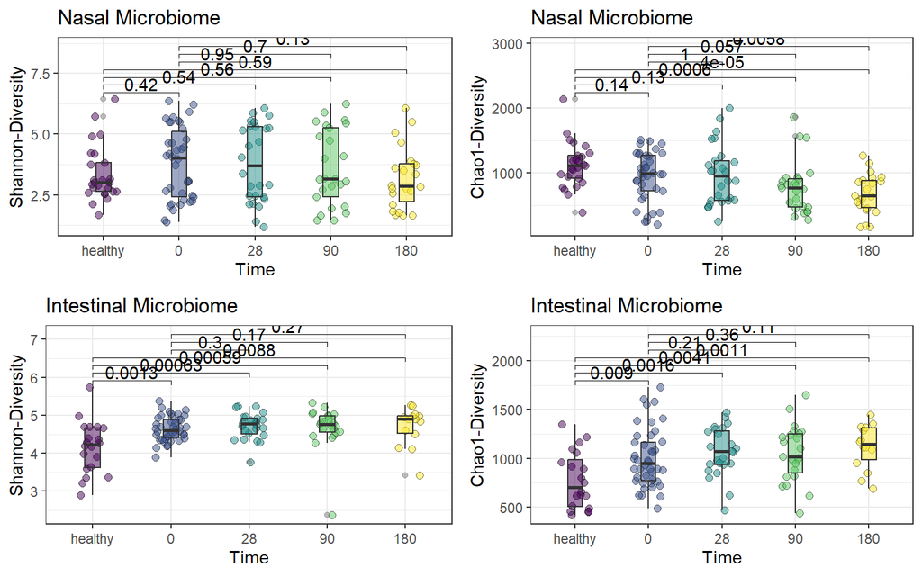

Shannon diversity in nasal and gut microbiome in patients with diffuse type 2 chronic rhinosinusitis under dupilumab treatment and healthy controls.

```r
# create boxplot including shannon diversity with wilcoxan rank test
p.shannon_stool <- boxplot_alpha(ASV_physeq_stool,
                           index = "shannon",
                           x_var = "Time") +
  stat_compare_means(method = "wilcox", step.increase = 0.06,
                     comparisons = list(c("healthy", "0"), c("healthy", "28"), c("healthy", "90"), c("healthy", "180"), c("0", "28"), c("0", "90"), c("0", "180"))) +
  scale_fill_viridis(discrete = TRUE, alpha = 1, option="viridis")+
  theme_bw()+
  ylab("Shannon-Diversity")+
  labs(title = "Intestinal Microbiome")

p.chao_stool <- boxplot_alpha(ASV_physeq_stool,
                           index = "chao1",
                           x_var = "Time") +
  stat_compare_means(method = "wilcox", step.increase = 0.06,
                     comparisons = list(c("healthy", "0"), c("healthy", "28"), c("healthy", "90"), c("healthy", "180"), c("0", "28"), c("0", "90"), c("0", "180"))) +
  scale_fill_viridis(discrete = TRUE, alpha = 1, option="viridis")+
  theme_bw()+
  ylab("Chao1-Diversity")+
  labs(title = "Intestinal Microbiome")

legend <- get_legend(p.shannon)
div <- ggarrange(p.shannon, p.chao, p.shannon_stool, p.chao_stool, nrow = 2, ncol = 2, legend = "none")
div
```

# Beta diversity

Now we conduct beta-diversity as instructed on the github webpage [course_2021_radboud](https://microbiome.github.io/course_2021_radboud/beta-diversity.html#examples-of-pcoa-with-different-settings).

We use Bray-Curtis distance for this analysis.

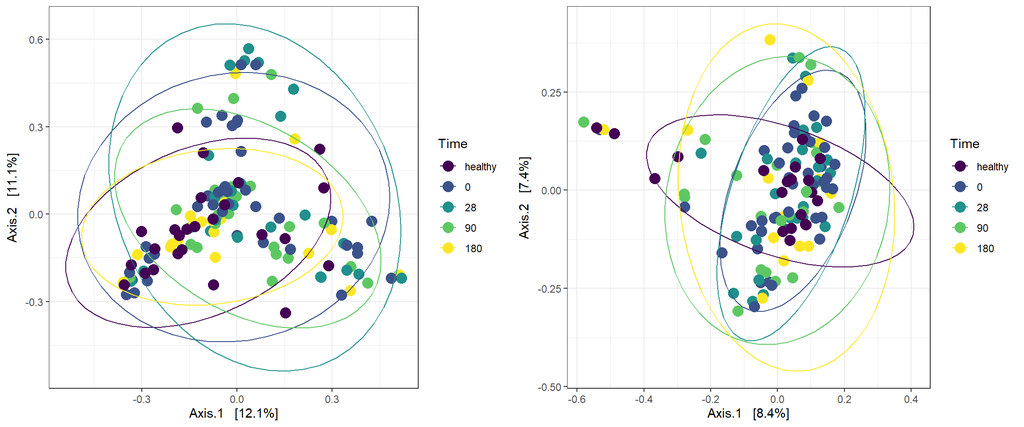

Bray-Curtis analysis nasal

```r
# with the phyloseq package we design a beta diversity plot
bray <- ordinate(ASV_physeq, method = "PCoA", distance = "bray")
beta1 <- plot_ordination(physeq = ASV_physeq, ordination = bray, color = "Time")+
  geom_point(size = 4)+
  stat_ellipse()+
  scale_color_viridis(discrete = TRUE)+
  theme_bw()

bray_stool <- ordinate(ASV_physeq_stool, method = "PCoA", distance = "bray")
beta2 <- plot_ordination(physeq = ASV_physeq_stool, ordination = bray_stool, color = "Time")+
  geom_point(size = 4)+
  stat_ellipse()+
  scale_color_viridis(discrete = TRUE)+
  theme_bw()

bt <- ggarrange(beta1, beta2, ncol =2)
bt
```

```r
# now we calculate the bray distance to test using PERMANOVA testing with 999 permutations.
abrel_bray <- phyloseq::distance(ASV_physeq, method = "bray")
sam <- data.frame(sample_data(ASV_physeq))
abrel_bray <- as.matrix(abrel_bray)

# our permanova test for healthy vs. CRS
sam_CRS <- sam[!is.na(sam$CRS_healthy), ]
abrel_bray_CRS <- abrel_bray[rownames(abrel_bray) %in% sam_CRS$SampleID, colnames(abrel_bray) %in% sam_CRS$SampleID]
permanova <- adonis2(abrel_bray_CRS ~ CRS_healthy, data = sam_CRS)

# our permanova test for healthy vs. d28
sam_CRS_d28 <- sam[!is.na(sam$healtyh_d28), ]
abrel_bray_CRS_d28 <- abrel_bray[rownames(abrel_bray) %in% sam_CRS_d28$SampleID, colnames(abrel_bray) %in% sam_CRS_d28$SampleID]
permanova <- adonis2(abrel_bray_CRS_d28 ~ healtyh_d28, data = sam_CRS_d28)

# our permanova test for healthy vs. d90
sam_CRS_d90 <- sam[!is.na(sam$healthy_d90), ]
abrel_bray_CRS_d90 <- abrel_bray[rownames(abrel_bray) %in% sam_CRS_d90$SampleID, colnames(abrel_bray) %in% sam_CRS_d90$SampleID]
permanova <- adonis2(abrel_bray_CRS_d90 ~ healthy_d90, data = sam_CRS_d90)

# our permanova test for healthy vs. d180
sam_180 <- sam[!is.na(sam$healthy_d180), ]
abrel_bray_180 <- abrel_bray[rownames(abrel_bray) %in% sam_180$SampleID, colnames(abrel_bray) %in% sam_180$SampleID]
permanova2 <- adonis2(abrel_bray_180 ~ healthy_d180, data = sam_180)

# our permanova test for d0 vs. d28
sam_28 <- sam[!is.na(sam$d0_d28), ]
abrel_bray_28 <- abrel_bray[rownames(abrel_bray) %in% sam_28$SampleID, colnames(abrel_bray) %in% sam_28$SampleID]
permanova2 <- adonis2(abrel_bray_28 ~ d0_d28, data = sam_28)

# our permanova test for d0 vs. d90
sam_90 <- sam[!is.na(sam$d0_d90), ]
abrel_bray_90 <- abrel_bray[rownames(abrel_bray) %in% sam_90$SampleID, colnames(abrel_bray) %in% sam_90$SampleID]
permanova2 <- adonis2(abrel_bray_90 ~ d0_d90, data = sam_90)

# our permanova test for d0 vs. d180
sam_180 <- sam[!is.na(sam$d0_180), ]
abrel_bray_180 <- abrel_bray[rownames(abrel_bray) %in% sam_180$SampleID, colnames(abrel_bray) %in% sam_180$SampleID]
permanova2 <- adonis2(abrel_bray_180 ~ d0_180, data = sam_180)
```

```r
# we do the same PERMANOVA analysis with the stool probes to test for similarity of the samples.

# now we calculate the bray distance to test using PERMANOVA testing with 999 permutations.
abrel_bray <- phyloseq::distance(ASV_physeq_stool, method = "bray")
sam <- data.frame(sample_data(ASV_physeq_stool))
abrel_bray <- as.matrix(abrel_bray)

# our permanova test for healthy vs. CRS
sam_CRS <- sam[!is.na(sam$CRS_healthy), ]
abrel_bray_CRS <- abrel_bray[rownames(abrel_bray) %in% sam_CRS$SampleID, colnames(abrel_bray) %in% sam_CRS$SampleID]
permanova <- adonis2(abrel_bray_CRS ~ CRS_healthy, data = sam_CRS)

# our permanova test for healthy vs. d28
sam_CRS_d28 <- sam[!is.na(sam$healtyh_d28), ]
abrel_bray_CRS_d28 <- abrel_bray[rownames(abrel_bray) %in% sam_CRS_d28$SampleID, colnames(abrel_bray) %in% sam_CRS_d28$SampleID]
permanova <- adonis2(abrel_bray_CRS_d28 ~ healtyh_d28, data = sam_CRS_d28)

# our permanova test for healthy vs. d90
sam_CRS_d90 <- sam[!is.na(sam$healthy_d90), ]
abrel_bray_CRS_d90 <- abrel_bray[rownames(abrel_bray) %in% sam_CRS_d90$SampleID, colnames(abrel_bray) %in% sam_CRS_d90$SampleID]
permanova <- adonis2(abrel_bray_CRS_d90 ~ healthy_d90, data = sam_CRS_d90)

# our permanova test for healthy vs. d180
sam_180 <- sam[!is.na(sam$healthy_d180), ]
abrel_bray_180 <- abrel_bray[rownames(abrel_bray) %in% sam_180$SampleID, colnames(abrel_bray) %in% sam_180$SampleID]
permanova2 <- adonis2(abrel_bray_180 ~ healthy_d180, data = sam_180)

# our permanova test for d0 vs. d28
sam_28 <- sam[!is.na(sam$d0_d28), ]
abrel_bray_28 <- abrel_bray[rownames(abrel_bray) %in% sam_28$SampleID, colnames(abrel_bray) %in% sam_28$SampleID]
permanova2 <- adonis2(abrel_bray_28 ~ d0_d28, data = sam_28)

# our permanova test for d0 vs. d90
sam_90 <- sam[!is.na(sam$d0_d90), ]
abrel_bray_90 <- abrel_bray[rownames(abrel_bray) %in% sam_90$SampleID, colnames(abrel_bray) %in% sam_90$SampleID]
permanova2 <- adonis2(abrel_bray_90 ~ d0_d90, data = sam_90)

# our permanova test for d0 vs. d180
sam_180 <- sam[!is.na(sam$d0_180), ]
abrel_bray_180 <- abrel_bray[rownames(abrel_bray) %in% sam_180$SampleID, colnames(abrel_bray) %in% sam_180$SampleID]
permanova2 <- adonis2(abrel_bray_180 ~ d0_180, data = sam_180)
```

### nasal microbiome

| Test | F-value | p-value |
| --- | --- | --- |
| healthy vs. CRS | 1.864 | 0.015* |
| healthy vs. d28 | 3.067 | 0.001*** |
| healthy vs. d90 | 2.941 | 0.001*** |
| healthy vs. d180 | 2.342 | 0.003** |
| d0 vs. d28 | 0.892 | 0.572 |
| d0 vs. d90 | 1.036 | 0.373 |
| d0 vs. d180 | 1.391 | 0.105 |

### stool microbiome

| Test | F-value | p-value |
| --- | --- | --- |
| healthy vs. CRS | 2.816 | 0.001*** |
| healthy vs. d28 | 2.372 | 0.001*** |
| healthy vs. d90 | 2.087 | 0.002** |
| healthy vs. d180 | 1.725 | 0.015* |
| d0 vs. d28 | 0.877 | 0.691 |
| d0 vs. d90 | 0.864 | 0.748 |
| d0 vs. d180 | 0.848 | 0.769 |

# Compositional Data

The next step is the evaluation of compositional data. We plot a stacked barplot to show the different genera in the nasal microbiome.

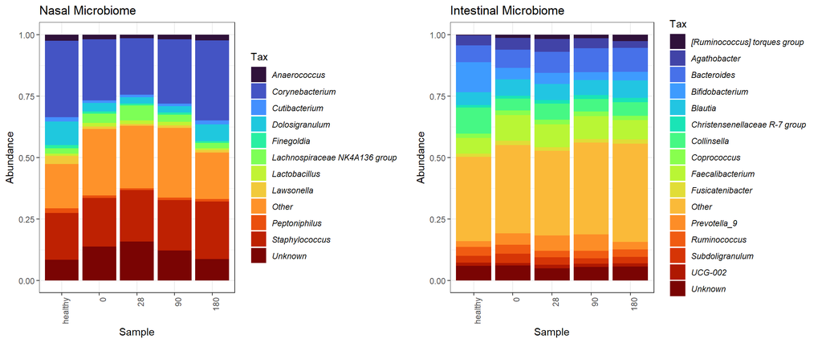

compositional data of *genera* level in the nasal microbiome of patients with chronic rhinosinusitis under dupilumab treatement

```r
# first make sure to use the right transform function
transform <- microbiome::transform

# use the abundance
pseq <- transform(ASV_physeq, "compositional")
pseq <- aggregate_rare(pseq, level = "Genus", detection = 1/100, prevalence = 20/100)

p1 <- plot_composition(pseq,
                      average_by = "Time",
                      transform = "compositional") +
  scale_fill_viridis(discrete = TRUE, option = "H") +
  theme_bw() +
  theme(axis.text.x = element_text(angle=90, hjust=1),
        legend.text = element_text(face = "italic"))+
  labs(title = "Nasal Microbiome")

# use the abundance
pseq_stool <- transform(ASV_physeq_stool, "compositional")
pseq_stool <- aggregate_rare(pseq_stool, level = "Genus", detection = 1/50, prevalence = 20/100)

p2 <- plot_composition(pseq_stool,
                      average_by = "Time",
                      transform = "compositional") +
  scale_fill_viridis(discrete = TRUE, option = "H") +
  theme_bw() +
  theme(axis.text.x = element_text(angle=90, hjust=1),
        legend.text = element_text(face = "italic"))+
  labs(title = "Intestinal Microbiome")

par <- ggarrange(p1, p2, ncol = 2)
par
```

The compositional data of the nasal microbiome shows a higher relative abundance of *Corynebacterium* in healthy controls compared to patients suffering from CRSwNP. On the other hand, the *Staphylococcus* genus level seems higher in CRSwNP patients. Comparing the stool microbiome, the *Bifidobacterium* are increased in healthy controls.

# Differential Abundance Analysis

To compare the different abundance of bacteria in the nasal microbiome. We conducted the analysis as described on the [DESeq2 homepage](https://joey711.github.io/phyloseq-extensions/DESeq2.html).

```r
# now we do the differential abundance analysis with the DESeq2 package
# we
ASV_CRS_healthy <- subset_samples(ASV_physeq, !is.na(CRS_healthy))
sample_data(ASV_CRS_healthy)$CRS_healthy <- as.factor(sample_data(ASV_CRS_healthy)$CRS_healthy)
# first we design a deseq2 object
diagdds = phyloseq_to_deseq2(ASV_CRS_healthy, ~ CRS_healthy)
diagdds = DESeq(diagdds, test="Wald", fitType="parametric")
```

```
-- replacing outliers and refitting for 21952 genes
-- DESeq argument 'minReplicatesForReplace' = 7
-- original counts are preserved in counts(dds)
```

```r
res = results(diagdds, cooksCutoff = FALSE)
alpha = 0.01
sigtab = res[which(res$padj < alpha), ]
sigtab = cbind(as(sigtab, "data.frame"), as(tax_table(ASV_physeq)[rownames(sigtab), ], "matrix"))
head(sigtab)
```

```
          baseMean log2FoldChange    lfcSE      stat       pvalue         padj
ASV_35   58.738137      -27.38190 2.967420 -9.227512 2.769907e-20 9.002197e-17
ASV_112   8.488849       23.22763 2.978795  7.797660 6.306574e-15 3.202557e-12
ASV_144 252.646436       27.97478 2.976981  9.397031 5.612423e-21 3.040062e-17
ASV_188  25.507493      -26.24232 2.967530 -8.843153 9.305450e-19 1.512136e-15
ASV_194  54.577915       25.80989 2.977211  8.669152 4.353508e-18 5.053178e-15
ASV_202  65.027869       26.07760 2.977164  8.759210 1.966239e-18 2.904671e-15
         Kingdom           Phylum               Class             Order
ASV_35  Bacteria Actinobacteriota      Actinobacteria Corynebacteriales
ASV_112 Bacteria Actinobacteriota      Actinobacteria Corynebacteriales
ASV_144 Bacteria       Firmicutes             Bacilli  Staphylococcales
ASV_188 Bacteria       Firmicutes             Bacilli  Staphylococcales
ASV_194 Bacteria       Firmicutes             Bacilli  Staphylococcales
ASV_202 Bacteria   Proteobacteria Gammaproteobacteria  Enterobacterales
                    Family           Genus     ASV
ASV_35  Corynebacteriaceae Corynebacterium  ASV_35
ASV_112 Corynebacteriaceae Corynebacterium ASV_112
ASV_144  Staphylococcaceae  Staphylococcus ASV_144
ASV_188  Staphylococcaceae  Staphylococcus ASV_188
ASV_194  Staphylococcaceae  Staphylococcus ASV_194
ASV_202    Pasteurellaceae     Haemophilus ASV_202
```

```r
x = tapply(sigtab$log2FoldChange, sigtab$Genus, function(x) max(x))
x = sort(x, TRUE)
sigtab$Genus = factor(as.character(sigtab$Genus), levels=names(x))
gg1 <- ggplot(sigtab, aes(x=Genus, y=log2FoldChange, color=padj)) +
  geom_point(size=6) +
  scale_x_discrete(guide = guide_axis(angle = -90))+
  theme_bw()+
  labs(title="healthy vs. CRS")+
  scale_color_viridis()
```

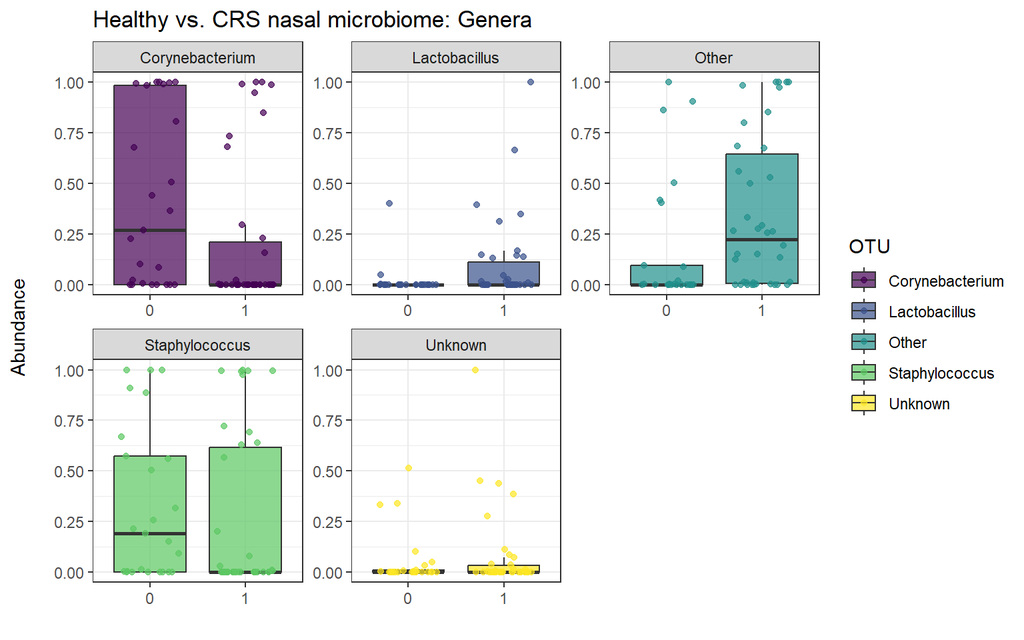

```r
# we add the siginificant ASV levels to our source data and plot the genus levels
MR_nasal <- count_tab_nasal[rownames(count_tab_nasal) %in% sigtab$ASV, ]
MR_tax_nasal <- tax_tab[rownames(tax_tab) %in% sigtab$ASV, ]

MR_count <- otu_table(MR_nasal, taxa_are_rows=T)
MR_tax <- tax_table(MR_tax_nasal)
sample_info_tab_phy <- sample_data(sample_info_tab)

MR_phy <- phyloseq(MR_count, MR_tax, sample_info_tab_phy)
transform <- microbiome::transform
pseq <- transform(MR_phy, "compositional")
pseq <- aggregate_rare(pseq, level = "Genus", detection = 1/100, prevalence = 20/100)

ps <- tax_glom(pseq, "Genus")
taxa_names(ps) <- tax_table(ps)[, "Genus"]

psmelt <- psmelt(ps)
psmelt <- psmelt[!is.na(psmelt$CRS_healthy),]
psmelt$CRS_healthy <- as.factor(psmelt$CRS_healthy)

g1 <- ggplot(data = psmelt, aes(x = CRS_healthy, y = Abundance, fill = OTU)) +
  geom_boxplot(outlier.shape = NA) +
  geom_jitter(aes(color = OTU), height = 0, width = .3) +
  labs(x = "", y = "Abundance\n", title = "Healthy vs. CRS nasal microbiome: Genera") +
  facet_wrap(~ OTU, scales = "free")+
  theme_bw()+
  scale_fill_viridis(discrete = TRUE, alpha = 0.7, option="viridis")+
  scale_color_viridis(discrete = TRUE, alpha = 0.7, option="viridis")
g1
```

```r
psmelt1 <- psmelt
```

```r
# now we do the differential abundance analysis with the DESeq2 package
# we
ASV_d28_healthy <- subset_samples(ASV_physeq, !is.na(healtyh_d28))
sample_data(ASV_d28_healthy)$healtyh_d28 <- as.factor(sample_data(ASV_d28_healthy)$healtyh_d28)
# first we design a deseq2 object
diagdds = phyloseq_to_deseq2(ASV_d28_healthy, ~ healtyh_d28)
diagdds = DESeq(diagdds, test="Wald", fitType="parametric")
```

```
-- replacing outliers and refitting for 19184 genes
-- DESeq argument 'minReplicatesForReplace' = 7
-- original counts are preserved in counts(dds)
```

```r
res = results(diagdds, cooksCutoff = FALSE)
alpha = 0.01
sigtab = res[which(res$padj < alpha), ]
sigtab = cbind(as(sigtab, "data.frame"), as(tax_table(ASV_physeq)[rownames(sigtab), ], "matrix"))
head(sigtab)
```

```
        baseMean log2FoldChange    lfcSE      stat       pvalue         padj
ASV_35  50.97781      -25.96721 2.913606 -8.912395 4.994198e-19 6.568203e-16
ASV_41  10.60811      -23.81072 2.913931 -8.171338 3.049880e-16 9.256387e-14
ASV_81  15.46855       23.84125 2.915651  8.176991 2.910188e-16 9.185719e-14
ASV_88  60.05929      -26.17884 2.913593 -8.985070 2.585695e-19 4.668419e-16
ASV_169 78.63608      -25.22174 2.913576 -8.656628 4.859266e-18 2.949575e-15
ASV_188 39.91089      -25.29830 2.913630 -8.682742 3.863408e-18 2.566498e-15
         Kingdom           Phylum          Class             Order
ASV_35  Bacteria Actinobacteriota Actinobacteria Corynebacteriales
ASV_41  Bacteria     Bacteroidota    Bacteroidia     Bacteroidales
ASV_81  Bacteria Actinobacteriota Actinobacteria Corynebacteriales
ASV_88  Bacteria Actinobacteriota Actinobacteria Corynebacteriales
ASV_169 Bacteria       Firmicutes        Bacilli   Lactobacillales
ASV_188 Bacteria       Firmicutes        Bacilli  Staphylococcales
                    Family           Genus     ASV
ASV_35  Corynebacteriaceae Corynebacterium  ASV_35
ASV_41      Bacteroidaceae     Bacteroides  ASV_41
ASV_81  Corynebacteriaceae Corynebacterium  ASV_81
ASV_88  Corynebacteriaceae Corynebacterium  ASV_88
ASV_169  Carnobacteriaceae  Dolosigranulum ASV_169
ASV_188  Staphylococcaceae  Staphylococcus ASV_188
```

```r
# we add the siginificant ASV levels to our source data and plot the genus levels
MR_nasal <- count_tab_nasal[rownames(count_tab_nasal) %in% sigtab$ASV, ]
MR_tax_nasal <- tax_tab[rownames(tax_tab) %in% sigtab$ASV, ]

MR_count <- otu_table(MR_nasal, taxa_are_rows=T)
MR_tax <- tax_table(MR_tax_nasal)
sample_info_tab_phy <- sample_data(sample_info_tab)

MR_phy <- phyloseq(MR_count, MR_tax, sample_info_tab_phy)
transform <- microbiome::transform
pseq <- transform(MR_phy, "compositional")
pseq <- aggregate_rare(pseq, level = "Genus", detection = 1/100, prevalence = 20/100)

ps <- tax_glom(pseq, "Genus")
taxa_names(ps) <- tax_table(ps)[, "Genus"]

psmelt <- psmelt(ps)
psmelt <- psmelt[!is.na(psmelt$healtyh_d28),]
psmelt$healtyh_d28 <- as.factor(psmelt$healtyh_d28)

g2 <- ggplot(data = psmelt, aes(x = healtyh_d28, y = Abundance, fill = OTU)) +
  geom_boxplot(outlier.shape = NA) +
  geom_jitter(aes(color = OTU), height = 0, width = .3) +
  labs(x = "", y = "Abundance\n", title = "Healthy vs. d28 nasal microbiome: Genera") +
  facet_wrap(~ OTU, scales = "free")+
  theme_bw()+
  scale_fill_viridis(discrete = TRUE, alpha = 0.7, option="viridis")+
  scale_color_viridis(discrete = TRUE, alpha = 0.7, option="viridis")
psmelt2 <- psmelt
```

```r
x = tapply(sigtab$log2FoldChange, sigtab$Genus, function(x) max(x))
x = sort(x, TRUE)
sigtab$Genus = factor(as.character(sigtab$Genus), levels=names(x))
gg2 <- ggplot(sigtab, aes(x=Genus, y=log2FoldChange, color=padj)) +
  geom_point(size=6) +
  scale_x_discrete(guide = guide_axis(angle = -90))+
  theme_bw()+
  labs(title="healthy vs. d28")+
  scale_color_viridis()
```

```r
# now we do the differential abundance analysis with the DESeq2 package
# we
ASV_d90_healthy <- subset_samples(ASV_physeq, !is.na(healthy_d90))
sample_data(ASV_d90_healthy)$healthy_d90 <- as.factor(sample_data(ASV_d90_healthy)$healthy_d90)
# first we design a deseq2 object
diagdds = phyloseq_to_deseq2(ASV_d90_healthy, ~ healthy_d90)
diagdds = DESeq(diagdds, test="Wald", fitType="parametric")
```

```
-- replacing outliers and refitting for 17487 genes
-- DESeq argument 'minReplicatesForReplace' = 7
-- original counts are preserved in counts(dds)
```

```r
res = results(diagdds, cooksCutoff = FALSE)
alpha = 0.01
sigtab = res[which(res$padj < alpha), ]
sigtab = cbind(as(sigtab, "data.frame"), as(tax_table(ASV_physeq)[rownames(sigtab), ], "matrix"))
head(sigtab)
```

```
          baseMean log2FoldChange    lfcSE      stat       pvalue         padj
ASV_35   27.430282      -25.22605 2.914322 -8.655888 4.890876e-18 3.499285e-15
ASV_84    7.615761      -23.38543 2.914976 -8.022512 1.036044e-15 3.336579e-13
ASV_88  108.042375      -27.04127 2.914134 -9.279348 1.705190e-20 4.371363e-17
ASV_112  10.107982       23.85588 2.916318  8.180139 2.835169e-16 1.106747e-13
ASV_169  57.047506      -25.20703 2.914191 -8.649751 5.161187e-18 3.499285e-15
ASV_188  35.435141      -25.53603 2.914265 -8.762427 1.910917e-18 1.641095e-15
         Kingdom           Phylum          Class             Order
ASV_35  Bacteria Actinobacteriota Actinobacteria Corynebacteriales
ASV_84  Bacteria     Bacteroidota    Bacteroidia     Bacteroidales
ASV_88  Bacteria Actinobacteriota Actinobacteria Corynebacteriales
ASV_112 Bacteria Actinobacteriota Actinobacteria Corynebacteriales
ASV_169 Bacteria       Firmicutes        Bacilli   Lactobacillales
ASV_188 Bacteria       Firmicutes        Bacilli  Staphylococcales
                    Family           Genus     ASV
ASV_35  Corynebacteriaceae Corynebacterium  ASV_35
ASV_84      Bacteroidaceae     Bacteroides  ASV_84
ASV_88  Corynebacteriaceae Corynebacterium  ASV_88
ASV_112 Corynebacteriaceae Corynebacterium ASV_112
ASV_169  Carnobacteriaceae  Dolosigranulum ASV_169
ASV_188  Staphylococcaceae  Staphylococcus ASV_188
```

```r
# we add the siginificant ASV levels to our source data and plot the genus levels
MR_nasal <- count_tab_nasal[rownames(count_tab_nasal) %in% sigtab$ASV, ]
MR_tax_nasal <- tax_tab[rownames(tax_tab) %in% sigtab$ASV, ]

MR_count <- otu_table(MR_nasal, taxa_are_rows=T)
MR_tax <- tax_table(MR_tax_nasal)
sample_info_tab_phy <- sample_data(sample_info_tab)

MR_phy <- phyloseq(MR_count, MR_tax, sample_info_tab_phy)
transform <- microbiome::transform
pseq <- transform(MR_phy, "compositional")
pseq <- aggregate_rare(pseq, level = "Genus", detection = 1/100, prevalence = 20/100)

ps <- tax_glom(pseq, "Genus")
taxa_names(ps) <- tax_table(ps)[, "Genus"]

psmelt <- psmelt(ps)
psmelt <- psmelt[!is.na(psmelt$healthy_d90),]
psmelt$healthy_d90 <- as.factor(psmelt$healthy_d90)

g3 <- ggplot(data = psmelt, aes(x = healthy_d90, y = Abundance, fill = OTU)) +
  geom_boxplot(outlier.shape = NA) +
  geom_jitter(aes(color = OTU), height = 0, width = .3) +
  labs(x = "", y = "Abundance\n", title = "Healthy vs. d90 nasal microbiome: Genera") +
  facet_wrap(~ OTU, scales = "free")+
  theme_bw()+
  scale_fill_viridis(discrete = TRUE, alpha = 0.7, option="viridis")+
  scale_color_viridis(discrete = TRUE, alpha = 0.7, option="viridis")
psmelt3 <- psmelt
```

```r
x = tapply(sigtab$log2FoldChange, sigtab$Genus, function(x) max(x))
x = sort(x, TRUE)
sigtab$Genus = factor(as.character(sigtab$Genus), levels=names(x))
gg3 <- ggplot(sigtab, aes(x=Genus, y=log2FoldChange, color=padj)) +
  geom_point(size=6) +
  scale_x_discrete(guide = guide_axis(angle = -90))+
  theme_bw()+
  labs(title="healthy vs. d90")+
  scale_color_viridis()
```

```r
# now we do the differential abundance analysis with the DESeq2 package
# we
ASV_d180_healthy <- subset_samples(ASV_physeq, !is.na(healthy_d180))
sample_data(ASV_d180_healthy)$healthy_d180 <- as.factor(sample_data(ASV_d180_healthy)$healthy_d180)
# first we design a deseq2 object
diagdds = phyloseq_to_deseq2(ASV_d180_healthy, ~ healthy_d180)
diagdds = DESeq(diagdds, test="Wald", fitType="parametric")
```

```
-- replacing outliers and refitting for 15426 genes
-- DESeq argument 'minReplicatesForReplace' = 7
-- original counts are preserved in counts(dds)
```

```r
res = results(diagdds, cooksCutoff = FALSE)
alpha = 0.01
sigtab = res[which(res$padj < alpha), ]
sigtab = cbind(as(sigtab, "data.frame"), as(tax_table(ASV_physeq)[rownames(sigtab), ], "matrix"))
head(sigtab)
```

```
          baseMean log2FoldChange    lfcSE      stat       pvalue         padj
ASV_81  324.987633       28.64353 2.919972  9.809519 1.024556e-22 1.937179e-19
ASV_88  127.373947      -26.90533 2.923850 -9.202022 3.512769e-20 3.320884e-17
ASV_91    7.462363      -23.00664 2.924738 -7.866223 3.655077e-15 8.376771e-13
ASV_169  96.425004      -26.53004 2.923867 -9.073612 1.151353e-19 7.916074e-17
ASV_188  35.576653      -25.15495 2.923992 -8.602947 7.769501e-18 2.798130e-15
ASV_202  31.411135       25.36866 2.920570  8.686203 3.747563e-18 1.574601e-15
         Kingdom           Phylum               Class             Order
ASV_81  Bacteria Actinobacteriota      Actinobacteria Corynebacteriales
ASV_88  Bacteria Actinobacteriota      Actinobacteria Corynebacteriales
ASV_91  Bacteria       Firmicutes          Clostridia    Lachnospirales
ASV_169 Bacteria       Firmicutes             Bacilli   Lactobacillales
ASV_188 Bacteria       Firmicutes             Bacilli  Staphylococcales
ASV_202 Bacteria   Proteobacteria Gammaproteobacteria  Enterobacterales
                    Family                           Genus     ASV
ASV_81  Corynebacteriaceae                 Corynebacterium  ASV_81
ASV_88  Corynebacteriaceae                 Corynebacterium  ASV_88
ASV_91     Lachnospiraceae [Ruminococcus] gauvreauii group  ASV_91
ASV_169  Carnobacteriaceae                  Dolosigranulum ASV_169
ASV_188  Staphylococcaceae                  Staphylococcus ASV_188
ASV_202    Pasteurellaceae                     Haemophilus ASV_202
```

```r
# we add the siginificant ASV levels to our source data and plot the genus levels
MR_nasal <- count_tab_nasal[rownames(count_tab_nasal) %in% sigtab$ASV, ]
MR_tax_nasal <- tax_tab[rownames(tax_tab) %in% sigtab$ASV, ]

MR_count <- otu_table(MR_nasal, taxa_are_rows=T)
MR_tax <- tax_table(MR_tax_nasal)
sample_info_tab_phy <- sample_data(sample_info_tab)

MR_phy <- phyloseq(MR_count, MR_tax, sample_info_tab_phy)
transform <- microbiome::transform
pseq <- transform(MR_phy, "compositional")
pseq <- aggregate_rare(pseq, level = "Genus", detection = 1/100, prevalence = 20/100)

ps <- tax_glom(pseq, "Genus")
taxa_names(ps) <- tax_table(ps)[, "Genus"]

psmelt <- psmelt(ps)
psmelt <- psmelt[!is.na(psmelt$healthy_d180),]
psmelt$healthy_d180 <- as.factor(psmelt$healthy_d180)

g4 <- ggplot(data = psmelt, aes(x = healthy_d180, y = Abundance, fill = OTU)) +
  geom_boxplot(outlier.shape = NA) +
  geom_jitter(aes(color = OTU), height = 0, width = .3) +
  labs(x = "", y = "Abundance\n", title = "Healthy vs. d90 nasal microbiome: Genera") +
  facet_wrap(~ OTU, scales = "free")+
  theme_bw()+
  scale_fill_viridis(discrete = TRUE, alpha = 0.7, option="viridis")+
  scale_color_viridis(discrete = TRUE, alpha = 0.7, option="viridis")
psmelt4 <- psmelt
```

```r
x = tapply(sigtab$log2FoldChange, sigtab$Genus, function(x) max(x))
x = sort(x, TRUE)
sigtab$Genus = factor(as.character(sigtab$Genus), levels=names(x))
gg4 <- ggplot(sigtab, aes(x=Genus, y=log2FoldChange, color=padj)) +
  geom_point(size=6) +
  scale_x_discrete(guide = guide_axis(angle = -90))+
  theme_bw()+
  labs(title="healthy vs. d180")+
  scale_color_viridis()
```

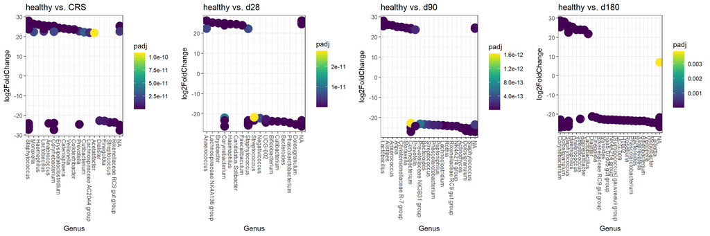

```r
gustav <- ggarrange(gg1, gg2, gg3, gg4, nrow = 1, ncol = 4)
gustav
```

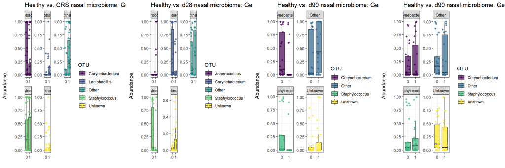

```r
gustav2 <- ggarrange(g1, g2, g3, g4, nrow = 1, ncol = 4)
gustav2
```

# abundance analysis Wilcoxan Test Nasal Microbiome

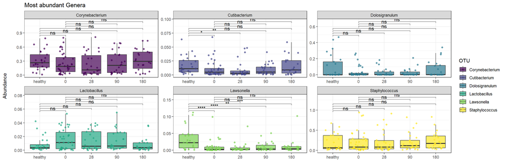

```r
transform <- microbiome::transform
pseq <- transform(ASV_physeq, "compositional")
pseq <- aggregate_rare(pseq, level = "Genus", detection = 1/100, prevalence = 10/100)

ps <- tax_glom(pseq, "Genus")
taxa_names(ps) <- tax_table(ps)[, "Genus"]

psmelt <- psmelt(ps)

psmelt_gesamt <- psmelt %>% filter(OTU %in% c("Staphylococcus", "Dolosigranulum", "Corynebacterium", "Lactobacillus", "Lawsonella", "Cutibacterium"))

my_comparisons = list(c("healthy", "0"), c("healthy", "28"), c("healthy", "90"), c("healthy", "180"), c("0", "28"), c("0", "90"), c("0", "180"))

gesamt <- ggplot(data = psmelt_gesamt, aes(x = Time, y = Abundance)) +
  geom_boxplot(outlier.shape = NA, aes(fill = OTU)) +
  geom_jitter(aes(color = OTU), height = 0, width = .3) +
  labs(x = "", y = "Abundance\n", title = "Most abundant Genera") +
  theme_bw()+
  facet_wrap(~ OTU, scales = "free")+
  stat_compare_means(comparison = my_comparisons, method = "wilcox", label = "p.signif", step.increase = 0.06)+
  #stat_compare_means(aes(group = OTU), method = "wilcox", label = "p.signif", step.increase = 0.06,
                     #comparisons = list(c("healthy", "0"), c("healthy", "28"), c("healthy", "90"), c("healthy", "180"), c("0", "28"), c("0", "90"), c("0", "180"))) +
  scale_fill_viridis(discrete = TRUE, alpha = 0.7, option="viridis")+
  scale_color_viridis(discrete = TRUE, alpha = 0.7, option="viridis")
gesamt
```

```r
statistics <- compare_means(Abundance ~ Time, psmelt_gesamt, group.by = "OTU", method = "wilcox.test", p.adjust.method = "holm")
statistics
```

```
# A tibble: 60 × 9
   OTU            .y.       group1  group2     p p.adj p.format p.signif method
   <chr>          <chr>     <chr>   <chr>  <dbl> <dbl> <chr>    <chr>    <chr>
 1 Staphylococcus Abundance healthy 0      0.917     1 0.91672  ns       Wilcox…
 2 Staphylococcus Abundance healthy 28     0.918     1 0.91819  ns       Wilcox…
 3 Staphylococcus Abundance healthy 90     0.513     1 0.51276  ns       Wilcox…
 4 Staphylococcus Abundance healthy 180    0.199     1 0.19908  ns       Wilcox…
 5 Staphylococcus Abundance 0       28     0.908     1 0.90818  ns       Wilcox…
 6 Staphylococcus Abundance 0       90     0.430     1 0.43014  ns       Wilcox…
 7 Staphylococcus Abundance 0       180    0.136     1 0.13560  ns       Wilcox…
 8 Staphylococcus Abundance 28      90     0.519     1 0.51889  ns       Wilcox…
 9 Staphylococcus Abundance 28      180    0.184     1 0.18374  ns       Wilcox…
10 Staphylococcus Abundance 90      180    0.466     1 0.46561  ns       Wilcox…
# ℹ 50 more rows
```